# Session 2: Introduction to Data Wrangling

Dan Killian and Ted Papalexopoulos

1/12/2021

# Agenda

1. The RStudio IDE
2. Introduction to R and R Basics
3. Introduction to the Tidyverse

# RStudio

Before we begin, let’s take a moment to go through the basics of RStudio.

# What is R

R is a programming language for statistical computing and graphics. Initially introduced in 1993, the language was designed specifically for working with data. R’s functionality is greatly enhanced by a massive repository of community-built packages (also referred to as libraries) which continue to extend and improve R’s power.

# R Basics

## Simple Calculator

You can use R as a calculator:

```r
1 / 200 * 30
```

```
## [1] 0.15
```

```r
(59 + 73 + 2) / 3
```

```
## [1] 44.66667
```

```r
sin(pi / 2)
```

```
## [1] 1
```

## Variable Assignments

You can create new objects with `<-`:

```r
three_times_four <- 3 * 4
```

All R statements where you create objects, **assignment** statements, have the same form:

```r
object_name <- value
```

When reading that code say “object name gets value” in your head.

> You can also use `=` instead of the assignment arrow (in early versions of R, this was not the case), however the standard convention is to use the assignment arrow for assignment statements and to use `=` when passing arguments inside of functions.

## Naming Convention

Object names must start with a letter, and can only contain letters, numbers, `_` and `.`. You want your object names to be descriptive, so you’ll need a convention for multiple words. **snake_case** is the recommended choice, where you separate lowercase words with `_`.

```r
i_use_snake_case
```

Also, capitalization matters!

```r
MIT_Cheer <- "Go Engineers"
```

Let’s try to inspect it:

```r
mit_cheer
```

```
#> Error: object 'mit_cheer' not found
```

```r
MIT_cheer
```

```
#> Error: object 'MIT_cheer' not found
```

## Vectors and Vectorization

The primary data type in R is the vector (as in a container vector, not a mathematical vector).

As such, even scalars like our variable from earlier `three_time_four` are actually vectors in R!

```r
three_times_four
```

```
## [1] 12
```

```r
is.vector(three_times_four)
```

```
## [1] TRUE
```

Vectors with more than one element are created using the concatenation function `c()`, as in

```r
vector_A <- c(1,2,3)
vector_B <- c(2,4,6)
```

The following subsection is intended to provide some insight for those of you who may be learning R after mastering another language such as C or Python without NumPy.

> Because R is a vector-oriented language, functions are naturally vectorized. If we wanted to divide element *i* of `vector_B` by element *i* of `vector_A` for *i* in 1 to 3, we can simply type `vector_B/vector_A` instead of needing to do the following:

```r
B_divided_by_A <- c()

for(i in 1:3){
  B_divided_by_A[i] <- vector_B[i]/vector_A[i]
}

B_divided_by_A == (vector_B/vector_A)
```

```
## [1] TRUE TRUE TRUE
```

> Another feature of R is that operations on vectors of different lengths do not cause an error. Instead, R recycles elements of the shorter vector until the shorter vector is the same length as the longer vector.

```r
c(1,1) + c(4,4,4,4)
```

```
## [1] 5 5 5 5
```

## Indexing Vectors and Dataframes

To discuss indexing, we will use the `cars` dataframe which is a preloaded dataframe containing two columns: `speed` and `distance`.

To access a single column of this dataframe, we use `$`. Here, we view the `speed` column from the `cars` dataframe.

```r
cars$speed
```

```
##  [1]  4  4  7  7  8  9 10 10 10 11 11 12 12 12 12 13 13 13 13 14 14 14 14 15 15
## [26] 15 16 16 17 17 17 18 18 18 18 19 19 19 20 20 20 20 20 22 23 24 24 24 24 25
```

To index a specific element(s) of a vector or dataframe, we use `[ ]`.

Here we select the first five elements of the `speed` vector. (Note that in R, the first element in indexed as element 1, not element 0 as in Python.)

```r
cars$speed[1:5]
```

```
## [1] 4 4 7 7 8
```

And here we select the first ten rows of the first column (the `speed` column) of the `cars` dataframe

```r
cars[1:10, 1]
```

```
##  [1]  4  4  7  7  8  9 10 10 10 11
```

Note that a vector only requires one position argument, while a dataframe requires both the row and column.

## Calling Functions

R has a large collection of built-in functions that are called like this:

```r
function_name(arg1 = val1, arg2 = val2, ...)
```

## Help with Functions

Oftentimes, you will need to reference the R documentation for a function. A quick way to do this is to use a single question mark ‘?’ followed by the function name.

```r
?summary()
```

# Let’s Get Started

Now that we’ve covered the basics, let’s jump in and start working with some data!

## Before we Begin…

Before we begin working with data, we need to make sure that R knows where to look for any data that we want to import and where to save any files we may create. To do this, we should check the *working directory*

```r
getwd()
```

```
## [1] "C:/Users/danie/Documents/GitHub/cos_2021/2_data_wrangling"
```

If the working directory is not correct, we need to *set the working directory* to the \GitHub_2021\2_data_wrangling folder. One easy to do this is in the Files tab using the “More” drop-down menu.

## Initial Steps

### Clear the Workspace

Whenever you begin working in R, it is usually (note that I said usually and not always) a good idea to clear your workspace.

```r
rm(list = ls())
```

### Load Packages

After clearing the workspace, the general convention is to first load in any packages that you intend to use in your script.

If you did the homework, you already installed the library we need, but if not, install it with: `install.packages('tidyverse')`.

Now that we have the libraries installed, we’ll load them into our current R session:

```r
library(tidyverse)
```

## Import and Explore our Data

Let’s load up the AirBnB data.

```r
raw_listings <- read_csv('../data/listings.csv')
```

We can look in Environment and see there’s actually 3,585 rows of 95 variables!

To get a clearer idea of what the data encompass we can use the ‘str’ command. This command displays the structure of an object:

```r
str(raw_listings)
```

```
## tibble [3,585 x 95] (S3: spec_tbl_df/tbl_df/tbl/data.frame)
##  $ id                              : num [1:3585] 12147973 3075044 6976 1436513 7651065 ...
##  $ listing_url                     : chr [1:3585] "https://www.airbnb.com/rooms/12147973" "https://www.airbnb.com/rooms/3075044" "https://www.airbnb.com/rooms/6976" "https://www.airbnb.com/rooms/1436513" ...
##  $ scrape_id                       : num [1:3585] 2.02e+13 2.02e+13 2.02e+13 2.02e+13 2.02e+13 ...
##  $ last_scraped                    : Date[1:3585], format: "2016-09-07" "2016-09-07" ...
##  $ name                            : chr [1:3585] "Sunny Bungalow in the City" "Charming room in pet friendly apt" "Mexican Folk Art Haven in Boston" "Spacious Sunny Bedroom Suite in Historic Home" ...
##  $ summary                         : chr [1:3585] "Cozy, sunny, family home.  Master bedroom high ceilings. Deck, garden with hens, beehives & play structure.   S"| __truncated__ "Charming and quiet room in a second floor 1910 condo building. The room has a full size bed, darkening curtains"| __t…
##  $ space                           : chr [1:3585] "The house has an open and cozy feel at the same time.  The living room has a flat screen TV.  The kitchen has a"| __truncated__ "Small but cozy and quite room with a full size bed. Ample street parking." "Come stay with a friendly, middle-aged gu…
##  $ description                     : chr [1:3585] "Cozy, sunny, family home.  Master bedroom high ceilings. Deck, garden with hens, beehives & play structure.   S"| __truncated__ "Charming and quiet room in a second floor 1910 condo building. The room has a full size bed, darkening curtains"| __t…
##  $ experiences_offered             : chr [1:3585] "none" "none" "none" "none" ...
##  $ neighborhood_overview           : chr [1:3585] "Roslindale is quiet, convenient and friendly.  For Southern food try Redd's in Rozzie.  Italian Delfino's or So"| __truncated__ "The room is in Roslindale, a diverse and primarily residential neighborhood of Boston. It's well connected via "| __t…
##  $ notes                           : chr [1:3585] NA "If you don't have a US cell phone, you can text me using (SENSITIVE CONTENTS HIDDEN)." "I am in a scenic part of Boston with a couple big parks nearby, and Jamaica Pond, where you can rent a sail boa"| __truncated__ "Please be mindful of the p…
##  $ transit                         : chr [1:3585] "The bus stop is 2 blocks away, and frequent. Bus is about a 10 minute ride to the Orange line, forest hills. Th"| __truncated__ "Plenty of safe street parking. Bus stops a few hundred feet from home. Buses 35, 36, or 37 will take you to the"| __t…
##  $ access                          : chr [1:3585] "You will have access to 2 bedrooms, a living room, kitchen, bathrooms, and yard." "Apt has one more bedroom (which I use) and large living space and kitchen that you can use.  Possibility to do "| __truncated__ "I am living in the apartment durin…
##  $ interaction                     : chr [1:3585] NA "If I am at home, I am likely working in my home office, which is a separate room. I can help you settle in and "| __truncated__ "ABOUT ME: I'm a laid-back, friendly, unmarried guy. I work from home, spending a lot of time on the computer. I"| …
##  $ house_rules                     : chr [1:3585] "Clean up and treat the home the way you'd like your home to be treated.  No smoking." "Pet friendly but please confirm with me if the pet you are planning on bringing with you is OK. I have a cute a"| __truncated__ "I encourage you to use my kitc…
##  $ thumbnail_url                   : chr [1:3585] "https://a2.muscache.com/im/pictures/c0842db1-ee98-4fe8-870b-d1e2af33855d.jpg?aki_policy=small" "https://a1.muscache.com/im/pictures/39327812/df0f1aab_original.jpg?aki_policy=small" "https://a2.muscache.com/im/pictures/6ae8335d-91e6-4598-b380-3129…
##  $ medium_url                      : chr [1:3585] "https://a2.muscache.com/im/pictures/c0842db1-ee98-4fe8-870b-d1e2af33855d.jpg?aki_policy=medium" "https://a1.muscache.com/im/pictures/39327812/df0f1aab_original.jpg?aki_policy=medium" "https://a2.muscache.com/im/pictures/6ae8335d-91e6-4598-b380-31…
##  $ picture_url                     : chr [1:3585] "https://a2.muscache.com/im/pictures/c0842db1-ee98-4fe8-870b-d1e2af33855d.jpg?aki_policy=large" "https://a1.muscache.com/im/pictures/39327812/df0f1aab_original.jpg?aki_policy=large" "https://a2.muscache.com/im/pictures/6ae8335d-91e6-4598-b380-3129…
##  $ xl_picture_url                  : chr [1:3585] "https://a2.muscache.com/im/pictures/c0842db1-ee98-4fe8-870b-d1e2af33855d.jpg?aki_policy=x_large" "https://a1.muscache.com/im/pictures/39327812/df0f1aab_original.jpg?aki_policy=x_large" "https://a2.muscache.com/im/pictures/6ae8335d-91e6-4598-b380-…
##  $ host_id                         : num [1:3585] 31303940 2572247 16701 6031442 15396970 ...
##  $ host_url                        : chr [1:3585] "https://www.airbnb.com/users/show/31303940" "https://www.airbnb.com/users/show/2572247" "https://www.airbnb.com/users/show/16701" "https://www.airbnb.com/users/show/6031442" ...
##  $ host_name                       : chr [1:3585] "Virginia" "Andrea" "Phil" "Meghna" ...
##  $ host_since                      : Date[1:3585], format: "2015-04-15" "2012-06-07" ...
##  $ host_location                   : chr [1:3585] "Boston, Massachusetts, United States" "Boston, Massachusetts, United States" "Boston, Massachusetts, United States" "Boston, Massachusetts, United States" ...
##  $ host_about                      : chr [1:3585] "We are country and city connecting in our deck and garden. Enjoy our music room, books and flat screen TV with "| __truncated__ "I live in Boston and I like to travel and have travelers staying at my place." "I am a middle-aged, single male with …
```

[output cut: 168 more lines]

The ‘summary’ command gives summary statistics

```r
summary(raw_listings)
```

```
##        id           listing_url          scrape_id          last_scraped
##  Min.   :    3353   Length:3585        Min.   :2.016e+13   Min.   :2016-09-07
##  1st Qu.: 4679319   Class :character   1st Qu.:2.016e+13   1st Qu.:2016-09-07
##  Median : 8577620   Mode  :character   Median :2.016e+13   Median :2016-09-07
##  Mean   : 8440875                      Mean   :2.016e+13   Mean   :2016-09-07
##  3rd Qu.:12789527                      3rd Qu.:2.016e+13   3rd Qu.:2016-09-07
##  Max.   :14933461                      Max.   :2.016e+13   Max.   :2016-09-07
##
##      name             summary             space           description
##  Length:3585        Length:3585        Length:3585        Length:3585
##  Class :character   Class :character   Class :character   Class :character
##  Mode  :character   Mode  :character   Mode  :character   Mode  :character
##
##
##
##
##  experiences_offered neighborhood_overview    notes
##  Length:3585         Length:3585           Length:3585
##  Class :character    Class :character      Class :character
##  Mode  :character    Mode  :character      Mode  :character
##
##
##
##
##    transit             access          interaction        house_rules
##  Length:3585        Length:3585        Length:3585        Length:3585
##  Class :character   Class :character   Class :character   Class :character
##  Mode  :character   Mode  :character   Mode  :character   Mode  :character
##
##
##
##
##  thumbnail_url       medium_url        picture_url        xl_picture_url
##  Length:3585        Length:3585        Length:3585        Length:3585
##  Class :character   Class :character   Class :character   Class :character
##  Mode  :character   Mode  :character   Mode  :character   Mode  :character
##
##
##
##
```

[output cut: 161 more lines]

```
##  Mode :logical                 Mode :logical
##  FALSE:3518                    FALSE:3348
##  TRUE :67                      TRUE :237
##
##
##
##
##  calculated_host_listings_count reviews_per_month
##  Min.   :  1.00                 Min.   : 0.010
##  1st Qu.:  1.00                 1st Qu.: 0.480
##  Median :  2.00                 Median : 1.170
##  Mean   : 12.73                 Mean   : 1.971
##  3rd Qu.:  6.00                 3rd Qu.: 2.720
##  Max.   :136.00                 Max.   :19.150
##                                 NA's   :756
```

The ‘colnames’ command displays just column names

```r
colnames(raw_listings)
```

```
##  [1] "id"                               "listing_url"
##  [3] "scrape_id"                        "last_scraped"
##  [5] "name"                             "summary"
##  [7] "space"                            "description"
##  [9] "experiences_offered"              "neighborhood_overview"
## [11] "notes"                            "transit"
## [13] "access"                           "interaction"
## [15] "house_rules"                      "thumbnail_url"
## [17] "medium_url"                       "picture_url"
## [19] "xl_picture_url"                   "host_id"
## [21] "host_url"                         "host_name"
## [23] "host_since"                       "host_location"
## [25] "host_about"                       "host_response_time"
## [27] "host_response_rate"               "host_acceptance_rate"
## [29] "host_is_superhost"                "host_thumbnail_url"
```

[output cut: 33 more lines]

A useful command is `table`, which quickly cross-tabulate counts of different variables. To see the count of how many listings are listed under each room type, we would type

```r
table(raw_listings$room_type)
```

```
##
## Entire home/apt    Private room     Shared room
##            2127            1378              80
```

## R Data Type Error and User-Defined Functions

Does anyone notice anything odd about the price column?

```r
summary(raw_listings$price)
```

```
##    Length     Class      Mode
##      3585 character character
```

Don’t worry if you didn’t. You typically don’t suspect data type errors until you try to do some sort of manipulation such as

```r
sum(raw_listings$price)
# >Error in sum(raw_listings$price) : invalid 'type' (character) of argument
```

R is telling us that the prices are character strings and not numeric.

Other vector types in R are `logical`, `integer`, `double`, `complex`, `character`, or `raw`.

The prices were given the type `character` because the column contains punctuation. But, we know they should be integers so we will write a function to correct this.

The ‘function()’ command allows us to create a function as an R object.

We will use the ‘gsub’ function to replace all occurences of a pattern with a new pattern.

The blackslash helps us escape special behavior.

```r
clean_price <- function(price) as.numeric(gsub('\\$|,', '', price))
```

## Motivation for the Tidyverse, Example 1

Even with the `summary` function, it is still challenging to figure out what’s in this dataset.

Let’s narrow our focus a little bit by just looking at two columns: `neighbourhood` and `price`.

To get just the first 10 rows of `raw_listings` and only the columns `neighbourhood` and `price`, we can type

```r
raw_listings[1:10, colnames(raw_listings) %in% c("neighbourhood","price")]
```

```
## # A tibble: 10 x 2
##    neighbourhood price
##    <chr>         <chr>
##  1 Roslindale    $250.00
##  2 Roslindale    $65.00
##  3 Roslindale    $65.00
##  4 <NA>          $75.00
##  5 Roslindale    $79.00
##  6 Roslindale    $75.00
##  7 <NA>          $100.00
##  8 Roslindale    $75.00
##  9 Roslindale    $58.00
## 10 Roslindale    $229.00
```

I don’t know about you but that seems like A LOT of typing to just get two columns! And, on top of that, this code is difficult to read!

There must be a better way….

## Motivation for the Tidyverse, Example 2

We may wish to be a little more focused in our investigation of our data. For this we can use “conditional” arguments, meaning a statement that can be answered by “true” or “false”. For example, we may be interested in exploring only those rooms that accomodate 4 or more people.

To determine the count of rooms by type that accommodate >= 4 people, we can type:

```r
table(raw_listings$room_type, raw_listings$accommodates >= 4)
```

```
##
##                   FALSE TRUE
##   Entire home/apt   969 1158
##   Private room     1303   75
##   Shared room        78    2
```

As in the previous motivating example, this code gets us what we want but again seems kind of messy.

I say again, there must be a better way!

# Introduction to the Tidyverse

Hadley Wickham, a statistician and computer scientist, introduced a suite of packages to give an elegant, unified approach to handling data in R (check out [the paper](http://vita.had.co.nz/papers/tidy-data.html)!). These data analysis tools, and the philosophy of data handling that goes with them, have become standard practice when using R.

The motivating observation is that data *tidying* and *preparation* consumes a majority of the data scientist’s time; the underlying concept is then to envision data wrangling in an idiomatic way.

To this end, Hadley developed a data cleaning philosophy and functions based on **verbs** and a nifty operator called the **chaining operator** which looks like `%>%` and serves like a pipeline from one function to another as in: `my_dataframe %>% My_Function == My_Function(my_dataframe)`.

The chaining operator feeds in the object on its left as the first argument into the function on its right.

## Feel the Power

Now that we’ve introduced the concept of the tidyverse, let’s see just how powerful it can be.

To start, remember this ugly subsetting code from above?

```r
raw_listings[1:10, colnames(raw_listings) %in% c("neighbourhood","price")]
```

Well, using the tidyverse, this becomes

```r
raw_listings %>%
  select(neighbourhood, price) %>%
  head(10)
```

```
## # A tibble: 10 x 2
##    neighbourhood price
##    <chr>         <chr>
##  1 Roslindale    $250.00
##  2 Roslindale    $65.00
##  3 Roslindale    $65.00
##  4 <NA>          $75.00
##  5 Roslindale    $79.00
##  6 Roslindale    $75.00
##  7 <NA>          $100.00
##  8 Roslindale    $75.00
##  9 Roslindale    $58.00
## 10 Roslindale    $229.00
```

(Here, we’ve used the `head` command and the input `10` to print out the first 10 elements)

What about that ugly table function from before?

```r
table(raw_listings$room_type, raw_listings$accommodates >= 4)
```

Using the tidyverse, this becomes

```r
raw_listings %>%
  filter(accommodates >= 4) %>%
  select(room_type) %>%
  table()
```

```
## .
## Entire home/apt    Private room     Shared room
##            1158              75               2
```

Isn’t that so much easier?! (Please excuse my enthusiasm.)

Compared to our previous example this is much easier to interpret.

Why?

- It is nicely organized
- It aligns with the way we as humans think

## Some Tidyverse Verbs

We just two tidyverse verbs. We saw how we can use:

- the `select` function to, you guessed it, **select** a specific column(s)
- the `filter` function to **filter** our table based on a specific condition(s)

Let’s look at some more verbs.

The `mutate` command allows us to add new variables (and thus new columns) to data, often by referring to existing ones.

```r
raw_listings %>%
  mutate(nprice = clean_price(price)) %>%
  select(name, price, nprice) %>%
  head()
```

```
## # A tibble: 6 x 3
##   name                                          price   nprice
##   <chr>                                         <chr>    <dbl>
## 1 Sunny Bungalow in the City                    $250.00    250
## 2 Charming room in pet friendly apt             $65.00      65
## 3 Mexican Folk Art Haven in Boston              $65.00      65
## 4 Spacious Sunny Bedroom Suite in Historic Home $75.00      75
## 5 Come Home to Boston                           $79.00      79
## 6 Private Bedroom + Great Coffee                $75.00      75
```

We can also `arrange` this info (sort it) to see the lowest- or highest-priced listings:

```r
raw_listings %>%
  mutate(nprice = clean_price(price)) %>%
  select(name, price, nprice) %>%
  arrange(nprice) %>%
  head()
```

```
## # A tibble: 6 x 3
##   name                                              price  nprice
##   <chr>                                             <chr>   <dbl>
## 1 MIT ROOM                                          $10.00     10
## 2 Easy-Sunny, Apt BU/Coolidge Corner                $11.00     11
## 3 Shared space for a girl 09/02-09/06               $20.00     20
## 4 One year from Sept, Harvard MIT Boston university $20.00     20
## 5 Affordable Boston, The dream of the 90's lives.   $22.00     22
## 6 I have a comfy couch for you to crash on          $22.00     22
```

(To see the highest-priced listings, notice the `desc()` embedded in the `arrange()` command)

```r
raw_listings %>%
  mutate(nprice = clean_price(price)) %>%
  select(name, price, nprice) %>%
  arrange(desc(nprice)) %>%
  head()
```

```
## # A tibble: 6 x 3
##   name                                          price     nprice
##   <chr>                                         <chr>      <dbl>
## 1 Fenway Park/Kenmore Square Flat               $4,000.00   4000
## 2 View of IndyCar...ON THE STREET!              $3,000.00   3000
## 3 短租 Boston地区 东北大学对面 三室两厅主卧出租 $1,400.00   1400
## 4 Super big private room                        $1,372.00   1372
## 5 1 bed Beacon Hill Close                       $1,345.00   1345
## 6 4+ BR Quiet, Deluxe, Charming House           $1,300.00   1300
```

Note that the tidyverse packages generally do not change the dataframe objects they act on.

For example, the code above doesn’t change `raw_listings`, but instead returns a new dataframe that has the same data as `raw_listings`, plus an extra column.

To learn another verb, let’s say we’re interested in understanding the relationship between bedrooms and price. But some of the listings don’t have data on bathrooms;

The `is.na()` function returns `TRUE` if something is `NA`, so `!is.na()` (read: “*not* is NA”) returns the opposite. (There is also a `is.nan()` function.)

The ‘sum’ command helps us count how many NA’s there are in a column as the logical `TRUE/FALSE` vector created by the `is.na()` function is converted to a binary numeric vector.

```r
raw_listings %>%
  select(bathrooms) %>%
  is.na() %>%
  sum()
```

```
## [1] 14
```

We could remove these records using

```r
raw_listings %>%
  filter(!is.na(bathrooms))
```

```
## # A tibble: 3,571 x 95
##        id listing_url scrape_id last_scraped name  summary space description
##     <dbl> <chr>           <dbl> <date>       <chr> <chr>   <chr> <chr>
##  1 1.21e7 https://ww~   2.02e13 2016-09-07   "Sun~ "Cozy,~ "The~ "Cozy, sun~
##  2 3.08e6 https://ww~   2.02e13 2016-09-07   "Cha~ "Charm~ "Sma~ "Charming ~
##  3 6.98e3 https://ww~   2.02e13 2016-09-07   "Mex~ "Come ~ "Com~ "Come stay~
##  4 1.44e6 https://ww~   2.02e13 2016-09-07   "Spa~ "Come ~ "Mos~ "Come expe~
##  5 7.65e6 https://ww~   2.02e13 2016-09-07   "Com~ "My co~ "Cle~ "My comfy,~
##  6 1.24e7 https://ww~   2.02e13 2016-09-07   "Pri~ "Super~ "Our~ "Super com~
##  7 5.71e6 https://ww~   2.02e13 2016-09-07   "New~ "It's ~ "The~ "It's a 5 ~
##  8 2.84e6 https://ww~   2.02e13 2016-09-07   "\"T~ "We ca~ "We ~ "We can ac~
##  9 7.53e5 https://ww~   2.02e13 2016-09-07   "6 m~ "Nice ~ "Nic~ "Nice and ~
## 10 8.49e5 https://ww~   2.02e13 2016-09-07   "Per~ "This ~ "Per~ "This is a~
## # ... with 3,561 more rows, and 87 more variables: experiences_offered <chr>,
## #   neighborhood_overview <chr>, notes <chr>, transit <chr>, access <chr>,
## #   interaction <chr>, house_rules <chr>, thumbnail_url <chr>,
## #   medium_url <chr>, picture_url <chr>, xl_picture_url <chr>, host_id <dbl>,
## #   host_url <chr>, host_name <chr>, host_since <date>, host_location <chr>,
## #   host_about <chr>, host_response_time <chr>, host_response_rate <chr>,
## #   host_acceptance_rate <chr>, host_is_superhost <lgl>,
## #   host_thumbnail_url <chr>, host_picture_url <chr>, host_neighbourhood <chr>,
## #   host_listings_count <dbl>, host_total_listings_count <dbl>,
## #   host_verifications <chr>, host_has_profile_pic <lgl>,
## #   host_identity_verified <lgl>, street <chr>, neighbourhood <chr>,
## #   neighbourhood_cleansed <chr>, neighbourhood_group_cleansed <lgl>,
## #   city <chr>, state <chr>, zipcode <chr>, market <chr>, smart_location <chr>,
## #   country_code <chr>, country <chr>, latitude <dbl>, longitude <dbl>,
## #   is_location_exact <lgl>, property_type <chr>, room_type <chr>,
## #   accommodates <dbl>, bathrooms <dbl>, bedrooms <dbl>, beds <dbl>,
## #   bed_type <chr>, amenities <chr>, square_feet <dbl>, price <chr>,
## #   weekly_price <chr>, monthly_price <chr>, security_deposit <chr>,
## #   cleaning_fee <chr>, guests_included <dbl>, extra_people <chr>,
## #   minimum_nights <dbl>, maximum_nights <dbl>, calendar_updated <chr>,
## #   has_availability <lgl>, availability_30 <dbl>, availability_60 <dbl>,
## #   availability_90 <dbl>, availability_365 <dbl>,
## #   calendar_last_scraped <date>, number_of_reviews <dbl>, first_review <date>,
## #   last_review <date>, review_scores_rating <dbl>,
## #   review_scores_accuracy <dbl>, review_scores_cleanliness <dbl>,
## #   review_scores_checkin <dbl>, review_scores_communication <dbl>,
## #   review_scores_location <dbl>, review_scores_value <dbl>,
## #   requires_license <lgl>, license <lgl>, jurisdiction_names <lgl>,
## #   instant_bookable <lgl>, cancellation_policy <chr>,
## #   require_guest_profile_picture <lgl>,
## #   require_guest_phone_verification <lgl>,
## #   calculated_host_listings_count <dbl>, reviews_per_month <dbl>
```

Finally, let’s combine some of these to make a clean dataset to work with.

We want to make sure our data has a correct price column and no missing bedroom or bathroom columns. We’ll assign it to a new dataframe named `listings`.

```r
listings <- raw_listings %>%
  filter(!is.na(bedrooms),
         !is.na(bathrooms)) %>%
  mutate(nprice = clean_price(price),
         weekly_price = clean_price(weekly_price),
         monthly_price = clean_price(monthly_price))
```

## Aggregation

Now, let’s see some summary statistics, like the average price for a listing? Let’s take our clean dataset and `summarize` it to find out.

```r
listings %>%
  summarise(avg.price = mean(nprice))
```

```
## # A tibble: 1 x 1
##   avg.price
##       <dbl>
## 1      174.
```

But what if we want to group our data by the variable `neighborhood_cleansed` and then calculate a mean for each individual group?

We can do this using the `group_by` function.

```r
listings %>%
  group_by(neighbourhood_cleansed) %>%
  summarize(avg.price = mean(nprice))
```

```
## # A tibble: 25 x 2
##    neighbourhood_cleansed avg.price
##    <chr>                      <dbl>
##  1 Allston                    112.
##  2 Back Bay                   241.
##  3 Bay Village                267.
##  4 Beacon Hill                225.
##  5 Brighton                   119.
##  6 Charlestown                198.
##  7 Chinatown                  232.
##  8 Dorchester                  91.9
##  9 Downtown                   236.
## 10 East Boston                119.
## # ... with 15 more rows
```

Whenever we use means, it is a good idea to check for outliers. The `n()` function gives a count of how many rows we have in each group.

> **Exercise:** How would we get not only the mean, but also the median and the size of each group?

> *Answer:*

```r
listings %>%
  group_by(neighbourhood_cleansed) %>%
  summarize(avg.price = mean(nprice),
            med.price = median(nprice),
            num = n())
```

```
## # A tibble: 25 x 4
##    neighbourhood_cleansed avg.price med.price   num
##    <chr>                      <dbl>     <dbl> <int>
##  1 Allston                    112.        85    260
##  2 Back Bay                   241.       209    299
##  3 Bay Village                267.       206.    24
##  4 Beacon Hill                225.       195    193
##  5 Brighton                   119.        90    185
##  6 Charlestown                198.       180    111
##  7 Chinatown                  232.       219     71
##  8 Dorchester                  91.9       73    267
##  9 Downtown                   236.       225    172
## 10 East Boston                119.        99    150
## # ... with 15 more rows
```

We do notice some red flags to our “mean” approach.

- First, if there are a very small number of listings in a neighborhood compared to the rest of the dataset, we may worry we don’t have a representative sample, or that this data point should be discredited somehow (on the other hand, maybe it’s just a small neighborhood, like Bay Village, and it’s actually outperforming expectation).
- Second, if the *median* is very different than the *mean* for a particular neighborhood, it indicates that we likely have *outliers* skewing the average. As a rule of thumb, means tend to be a misleading statistic to use with things like rent prices or incomes since outliers have such a large effect.

One thing we can do is just filter out any neighborhood below a threshold count:

```r
listings %>%
  group_by(neighbourhood_cleansed) %>%
  summarize(avg.price = mean(nprice),
            med.price = median(nprice),
            num = n()) %>%
  filter(num > 200)
```

```
## # A tibble: 6 x 4
##   neighbourhood_cleansed avg.price med.price   num
##   <chr>                      <dbl>     <dbl> <int>
## 1 Allston                    112.        85    260
## 2 Back Bay                   241.       209    299
## 3 Dorchester                  91.9       73    267
## 4 Fenway                     220.       190    288
## 5 Jamaica Plain              139.       100    342
## 6 South End                  204.       180.   318
```

We can also pick a few neighborhoods to look at by using the `%in%` keyword within a `filter`command with a list of the neighborhoods we want. We use the ‘c()’ function to combine its arguments in a vector.

```r
listings %>%
  filter(neighbourhood_cleansed %in% c('Downtown',
                                       'Back Bay',
                                       'Chinatown')) %>%
  group_by(neighbourhood_cleansed) %>%
  summarize(avg.price = mean(nprice),
            med.price = median(nprice),
            num = n()) %>%
  arrange(med.price)
```

```
## # A tibble: 3 x 4
##   neighbourhood_cleansed avg.price med.price   num
##   <chr>                      <dbl>     <dbl> <int>
## 1 Back Bay                    241.       209   299
## 2 Chinatown                   232.       219    71
## 3 Downtown                    236.       225   172
```

We have now seen: `select`, `filter`, `count`, `summarize`, `mutate`, `group_by`, and `arrange`. This is the majority of the dplyr “verbs” for operating on a single data table (although [there are many more](https://cran.r-project.org/web/packages/dplyr/dplyr.pdf)), but as you can see, learning new verbs is pretty intuitive. What we have already gives us enough tools to accomplish a large swath of data analysis tasks.

# Diving Deeper into the Tidy Data Philosophy

**Question:** Consider the following data below. How many variables does this dataset contain?

| Company | Qtr.1 | Qtr.2 | Qtr.3 | Qtr.4 |
| --- | --- | --- | --- | --- |
| ABC | $134.01 | $256.77 | $1788.23 | $444.37 |
| XYZ | $2727.11 | $567.23 | $321.01 | $4578.99 |
| GGG | $34.31 | $459.01 | $123.81 | $5767.01 |

> Raw data in the real-world is often `untidy` and poorly formatted.

## What is Tidy Data?

A dataset is said to be tidy if it satisfies the following conditions

1. Each variable must have its own column.
2. Each observation must have its own row.
3. Each value must have its own cell.

Sounds simple, right? Yet a lot of data isn’t formed that way, as we just saw.

In the tidyverse, we’d rather have the table represent “quarterly earnings,” with each row containing a single observation of a single quarter for a single company, and columns representing the company, quarter, and earning.

Something like this:

| Company | Quarter | Earnings |
| --- | --- | --- |
| ABC | Qtr.1 | $134.01 |
| ABC | Qtr.2 | $256.77 |
| ABC | Qtr.3 | $1788.23 |
| … | … | … |

## Why Tidy Data?

Consider the first table of quarterly earning data, which we say is in a  
**wide** format, and the second table of quarterly earning data, which we say is in a **long** format.

Suppose we wanted to compare each company’s earnings from the first half of the year to their earnings from the second half of the year.

How would we do that in the first case? It’d be an ugly and manual process. In the second case, we can run:

```r
quarterly_earnings %>%
  mutate(Part_of_Year = ifelse(Quarter %in% c("Qtr.1","Qtr.2"),
                               "First_Half",
                               "Second_Half")) %>%
  group_by(Company, Part_of_Year) %>%
  summarise(Earnings = sum(Earnings))
```

Simply put, tidy data and the tidyverse makes it easy to carry out data analysis.

### Causes of Messiness

- Column headers are values, not variable names
- Multiple variables are stored in one column
- Variables are stored in both rows and columns
- Multiple types of experimental unit stored in the same table
- One type of experimental unit stored in multiple tables

## Pivotting Dataframes (aka Reshaping our Data)

Think about our `listings` dataset. Doesn’t our data have specific columns for daily, weekly, and monthly prices?

This is not always an issue, but can become one, especially when we try to build a graph comparing the distributions of daily, weekly, and monthly prices.

We have a similar situation to the quarterly earnings example from before. We want each row to have single price, and have one of the columns specify which kind of price we’re talking about.

We have **wide** data when it comes to price and we would like **long** data.

You may be thinking by now, “Certainly, there must be an easy function for this with some sort of intuitive name such as `pivot_longer`!” and you would be correct.

To pivot **wide** data into a **long** format, we can use the `pivot_longer` function.

```r
long_price <- listings %>%
  select(id, name, nprice, weekly_price, monthly_price) %>%
  pivot_longer(cols = c("nprice", "weekly_price", "monthly_price"),
               names_to = "price_type",
               values_to = "price_value") %>%
  filter(!is.na(price_value))

long_price %>% head()  # take a peek
```

```
## # A tibble: 6 x 4
##         id name                              price_type    price_value
##      <dbl> <chr>                             <chr>               <dbl>
## 1 12147973 Sunny Bungalow in the City        nprice                250
## 2  3075044 Charming room in pet friendly apt nprice                 65
## 3  3075044 Charming room in pet friendly apt weekly_price          400
## 4     6976 Mexican Folk Art Haven in Boston  nprice                 65
## 5     6976 Mexican Folk Art Haven in Boston  weekly_price          395
## 6     6976 Mexican Folk Art Haven in Boston  monthly_price        1350
```

Let’s break down what `pivot_longer` does:

- The first argument is the columns that we would like to combine.
- The second argument is the name of the new column which will store the column names from the columns that we are combining.
- The third argument is the name of the new column that will contain the values from the column we are combining.

> **Exercise:** What’s the `pivot_longer` command for the quarterly earnings table above?

> *Answer:*

```r
pivot_longer(cols = c("Qtr.1", "Qtr.2", "Qtr.3", "Qtr.4")
             names_to = "Quarter",
             values_to = "Earnings")
```

> **Exercise:** How could we get `long_price` back into it’s original, wide format? (Hint: look at the help for `pivot_longer`.)

> *Answer:* To pivot the data back into its original wide format, we can use `pivot_wider`.

```r
pivot_wider(long_price,
            names_from = price_type,
            values_from = price_value) %>%
  head()
```

```
## # A tibble: 6 x 5
##         id name                                nprice weekly_price monthly_price
##      <dbl> <chr>                                <dbl>        <dbl>         <dbl>
## 1 12147973 Sunny Bungalow in the City             250           NA            NA
## 2  3075044 Charming room in pet friendly apt       65          400            NA
## 3     6976 Mexican Folk Art Haven in Boston        65          395          1350
## 4  1436513 Spacious Sunny Bedroom Suite in Hi~     75           NA            NA
## 5  7651065 Come Home to Boston                     79           NA            NA
## 6 12386020 Private Bedroom + Great Coffee          75           NA            NA
```

There are lots of times we need this little “trick,” so you should get comfortable with it

## Joining datasets

Our last topic will be how to **join** two data frames together.  
We’ll introduce the concept with two toy data frames, then apply it to our AirBnB data.

### Join together, right now, over me…

(The following example adapted from [here](https://rpubs.com/bradleyboehmke/data_wrangling).)

Let’s say `table1` is

```
##     name instrument
## 1   Paul       Bass
## 2   John     Guitar
## 3 George     Guitar
## 4  Ringo      Drums
```

and `table2` is

```
##     name member
## 1   John    yes
## 2 George    yes
## 3   Jimi     no
## 4  Ringo    yes
## 5  Sting     no
```

We might want to join these datasets so that we have a `name`, `instrument`, and `member` column, and the correct information filled in from both tables (with NAs wherever we’re missing the info). This operation is called a `full_join` and would give us this:

```r
full_join(table1, table2, by='name')
```

```
##     name instrument member
## 1   Paul       Bass   <NA>
## 2   John     Guitar    yes
## 3 George     Guitar    yes
## 4  Ringo      Drums    yes
## 5   Jimi       <NA>     no
## 6  Sting       <NA>     no
```

Notice we have to specify a **key** column to join `by`, in this case `name`.

We might also want to make sure we keep all the rows from the first table (the “left” table) but only add rows from the second (“right”) table if they match existing ones from the first. This called a `left_join` and gives us

```r
left_join(table1, table2, by='name')
```

```
##     name instrument member
## 1   Paul       Bass   <NA>
## 2   John     Guitar    yes
## 3 George     Guitar    yes
## 4  Ringo      Drums    yes
```

since “Jimi” and “Sting” don’t appear in the `name` column of `table1`.

Left and full joins are both called “outer joins” (you might think of merging two circles of a Venn diagram, and keeping all the non-intersecting “outer” parts). However, we might want to use only rows whose key values occur in both tables (the intersecting “inner” parts) — this is called an `inner_join` and gives us

```r
inner_join(table1, table2, by='name')
```

```
##     name instrument member
## 1   John     Guitar    yes
## 2 George     Guitar    yes
## 3  Ringo      Drums    yes
```

There is also `semi_join`, `anti_join`, ways to handle coercion, ways to handle different column names …

we don’t have time to cover all the variations here, but let’s try using some basic concepts on our AirBnB data.

### Applying joins

Let’s say we have a tidy table of the number of bathrooms and bedrooms for each listing, which we get by doing

```r
rooms <- listings %>%
  select(name, bathrooms, bedrooms) %>%
  pivot_longer(cols = c("bathrooms","bedrooms"),
               names_to = "room_type",
               values_to = "number")
```

But we may also want to look at the distribution of daily prices, which we can store as

```r
prices <- listings %>%
  select(name, nprice) %>%
  mutate(price = as.numeric(gsub('\\$|,', '', nprice)))
```

Now, we can do a full join to add a `price` column.

```r
rooms_prices <- full_join(rooms, prices, by='name')
```

This gives us a table with the number of bed/bathrooms separated out in a tidy format (so it is amenable to ggplot), but also prices tacked on each row (so we can incorporate that into the visualization).

Let’s try a boxplot of price, by number of rooms, and use facets to separate out the two different types of room.  
(We will also filter out half-rooms just to help clean up the plot.)

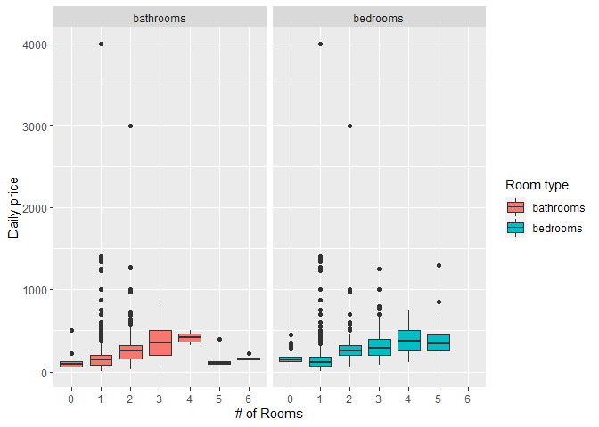

```r
rooms_prices %>%
  filter(!is.na(number), number %% 1 == 0) %>%
  mutate(number = as.factor(number)) %>%
  ggplot(aes(x = number,
             y = price,
             fill = room_type)) +
  geom_boxplot() +
  facet_grid(~room_type) +
  labs(x = '# of Rooms',
       y = 'Daily price',
       fill = 'Room type')
```

# Conclusion

In this session, we introduced some basics of data wrangling and visualization in R.  
Specifically, we introduced the powerful framework of the “Tidyverse”, discussed some of the elegant data philosophy behind these libraries, and briefly covered some more involved operations like pivot_wider/pivot_longer and dataset joins..

## Further reading

The best way to learn R, and data analysis in general, is not to read blogs and papers, but to *get out there and do it*.

There are always intriguing competitions on data hosting websites like [Kaggle](http://www.kaggle.com), and there many areas like [sports analytics](http://www.footballoutsiders.com), [political forecasting](http://www.electoral-vote.com/evp2016/Info/data.html), [historical analysis](https://t.co/3WCaDxGnJR), and countless others that have [clean](http://http://www.pro-football-reference.com/), [open](http://www.kdnuggets.com/datasets/index.html), and interesting data just waiting for you to `read_csv`.

You don’t need proprietary data [to make headlines](http://fivethirtyeight.com/features/a-plagiarism-scandal-is-unfolding-in-the-crossword-world/), and some data that seems like it would be hard to get is actually [out there in the wild](https://www.kaggle.com/kaggle/hillary-clinton-emails).

These are hobbyist applications, but we also hope this session has sparked your interest in applying analytics to your own research. Nearly every modern research field has been touched by the power and pervasiveness of data, and having the tools to take advantage of this in your field is a skill with increasing value.

And plus, it’s pretty fun.